# Predicting delays in commercial flights - DS Challenge ITA 2024

## Data

Let's start by exploring the data available at the 'public.csv' file. Of course, we'll use pandas to manipulate our data.

```
<class 'pandas.core.frame.DataFrame'>
RangeIndex: 302399 entries, 0 to 302398
Data columns (total 10 columns):
 #   Column                         Non-Null Count   Dtype
---  ------                         --------------   -----
 0   flightid                       302399 non-null  object
 1   hora_ref                       302399 non-null  datetime64[ns, UTC]
 2   origem                         302399 non-null  object
 3   destino                        302399 non-null  object
 4   url_img_satelite               298666 non-null  object
 5   metaf                          155737 non-null  object
 6   metar                          300770 non-null  object
 7   prev_troca_cabeceira           302399 non-null  int64
 8   troca_cabeceira_hora_anterior  302399 non-null  int64
 9   espera                         211679 non-null  float64
dtypes: datetime64[ns, UTC](1), float64(1), int64(2), object(6)
memory usage: 23.1+ MB
```

```
<class 'pandas.core.frame.DataFrame'>
RangeIndex: 302399 entries, 0 to 302398
Columns: 122 entries, flightid to remarks_destino_metaf
dtypes: float64(79), int64(2), object(41)
memory usage: 281.5+ MB
```

```
<class 'pandas.core.frame.DataFrame'>
Index: 211679 entries, 0 to 211678
Columns: 122 entries, flightid to remarks_destino_metaf
dtypes: float64(79), int64(2), object(41)
memory usage: 198.6+ MB
```

```
(169343, 122) (169343,)
(42336, 122) (42336,)
0.0174 0.0174
```

## Data exploration & visualization

Let's visualize the data we're working with so we can get some insights from it.

### Time information

The time information is given for each flight through the *hora_ref* column. According to some previous studies on flight delay prediction, time is often a relevant predictor. In fact, according to [this](https://repositorio.ufu.br/handle/123456789/30528), the period of the day and of the week was found to be a great predictor for delays in flights from an airport in Brazil. Therefore, we will first create two new features called *period_day* and *day_of_week* that express exactly these two predictors.

| period_day | count | mean |
| --- | --- | --- |
| evening | 36476 | 0.024948 |
| noon | 37426 | 0.019051 |
| night | 19974 | 0.018274 |
| morning | 45581 | 0.014151 |
| early morning | 9000 | 0.013222 |
| late night | 20886 | 0.009432 |

| day_of_week | count | mean |
| --- | --- | --- |
| 1 | 25115 | 0.022974 |
| 4 | 25759 | 0.019294 |
| 3 | 25599 | 0.018360 |
| 2 | 25697 | 0.017667 |
| 0 | 25770 | 0.015716 |
| 6 | 20408 | 0.015043 |
| 5 | 20995 | 0.011384 |

### Position, departure, arrival

Position of the flights is given by two columns: *origem* and *destino*.

```
origem
SBPA    0.025155
SBFL    0.024497
SBGL    0.023955
SBSV    0.022987
SBCT    0.022367
SBRJ    0.018936
SBRF    0.017727
SBCF    0.017401
SBBR    0.016557
SBSP    0.015037
SBKP    0.012369
SBGR    0.009549
Name: espera, dtype: float64
```

```
destino
SBSP    0.035056
SBRJ    0.033342
SBKP    0.019441
SBGR    0.015695
SBCF    0.012942
SBCT    0.012180
SBFL    0.011115
SBGL    0.006661
SBPA    0.004432
SBBR    0.002971
SBRF    0.002866
SBSV    0.002844
Name: espera, dtype: float64
```

Some airports have much more delays than others, therefore origem and destino can be good features.

| route | count | mean |
| --- | --- | --- |
| SBKP-SBSP | 21 | 0.142857 |
| SBGL-SBRJ | 76 | 0.131579 |
| SBGL-SBSP | 130 | 0.100000 |
| SBRF-SBFL | 13 | 0.076923 |
| SBGR-SBSP | 95 | 0.063158 |
| ... | ... | ... |
| SBCF-SBGL | 19 | 0.000000 |
| SBRF-SBPA | 69 | 0.000000 |
| SBFL-SBCT | 61 | 0.000000 |
| SBFL-SBBR | 455 | 0.000000 |
| SBCT-SBSV | 27 | 0.000000 |

129 rows × 2 columns

Origem and destino, hereforth combined and called route, seem to be a good predictor of delays.

### METAR/METAF data

There are many columns related to the metar/metaf data. Let's explore this data to get some insights about what we're working with.

First, let's combine the metar and metaf data by filling the na of the metar data with the information from the metaf reports, and, for numerical features, averaging them in case they both exist. This is a fair assumption since these reports should give similar information and serve as a complement to each other when no information is given by the other.

```
<class 'pandas.core.frame.DataFrame'>
Index: 169343 entries, 57224 to 54718
Data columns (total 85 columns):
 #   Column                            Non-Null Count   Dtype
---  ------                            --------------   -----
 0   flightid                          169343 non-null  object
 1   hora_ref                          169343 non-null  object
 2   origem                            169343 non-null  object
 3   destino                           169343 non-null  object
 4   url_img_satelite                  166993 non-null  object
 5   metaf                             71828 non-null   object
 6   metar                             168045 non-null  object
 7   prev_troca_cabeceira              169343 non-null  int64
 8   troca_cabeceira_hora_anterior     169343 non-null  int64
 9   espera                            169343 non-null  float64
```

[output cut: 77 more lines]

#### Cloud information

Cloud information is given in two ways: the clouds type and the clouds level. More about this can be found [here](https://www.chiaerospace.com/post/how-to-read-a-metar).

|  | low_cloud_type_origem | low_cloud_type_destino | medium_cloud_type_origem | medium_cloud_type_destino | high_cloud_type_origem | high_cloud_type_destino | highest_cloud_type_origem | highest_cloud_type_destino |
| --- | --- | --- | --- | --- | --- | --- | --- | --- |
| count | 114757 | 118201 | 61501 | 63132 | 18151 | 19427 | 1143 | 1217 |
| unique | 6 | 7 | 4 | 4 | 4 | 4 | 3 | 3 |
| top | FEW | FEW | BKN | BKN | BKN | BKN | BKN | BKN |
| freq | 40573 | 41495 | 28008 | 28583 | 9513 | 10197 | 744 | 794 |

```
                       count      mean
low_cloud_type_origem
VV                       205  0.024390
BKN                    27106  0.021213
SCT                    36600  0.020874
FEW                    40573  0.020087
OVC                     7145  0.012876
NSC                     3128  0.009910
                        count      mean
low_cloud_type_destino
NCD                       141  0.028369
BKN                     27520  0.023583
VV                        172  0.023256
SCT                     38551  0.020337
FEW                     41495  0.020051
NSC                      2827  0.017687
OVC                      7495  0.016144
                          count      mean
medium_cloud_type_origem
FEW                       10580  0.033554
OVC                        9614  0.020595
SCT                       13299  0.020453
BKN                       28008  0.020244
                           count      mean
medium_cloud_type_destino
FEW                        11555  0.037300
BKN                        28583  0.027849
OVC                         9743  0.025352
SCT                        13251  0.019470
                        count      mean
high_cloud_type_origem
SCT                      1923  0.030681
BKN                      9513  0.027016
FEW                      1562  0.026248
OVC                      5153  0.023093
                         count      mean
high_cloud_type_destino
FEW                       1671  0.073609
OVC                       5348  0.047120
BKN                      10197  0.031676
SCT                       2211  0.026685
                           count      mean
highest_cloud_type_origem
FEW                           63  0.063492
BKN                          744  0.047043
OVC                          336  0.023810
                            count      mean
highest_cloud_type_destino
OVC                           372  0.086022
BKN                           794  0.054156
FEW                            51  0.039216
```

Clearly, the delays increase when higher clouds are reported. This indicates that this set of predictors might be relevant for the model.

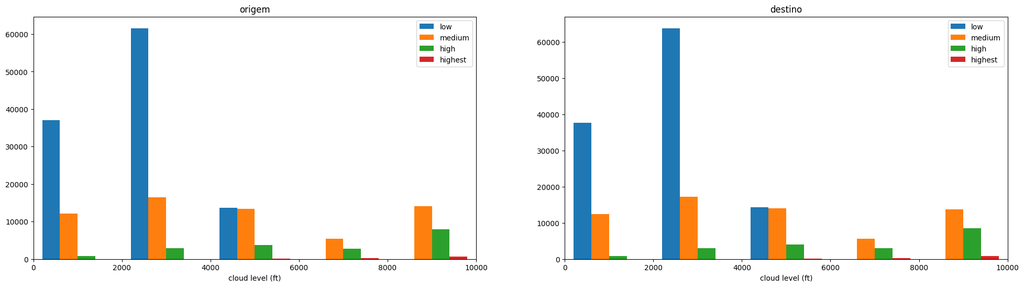

Some conclusions from this visualization:

Before moving forward, let's fill the nan of these columns using 10000, which represents an "infinite ceiling" in metar reports.

Let's now have a look at how these predictors relate to the delay of the flights.

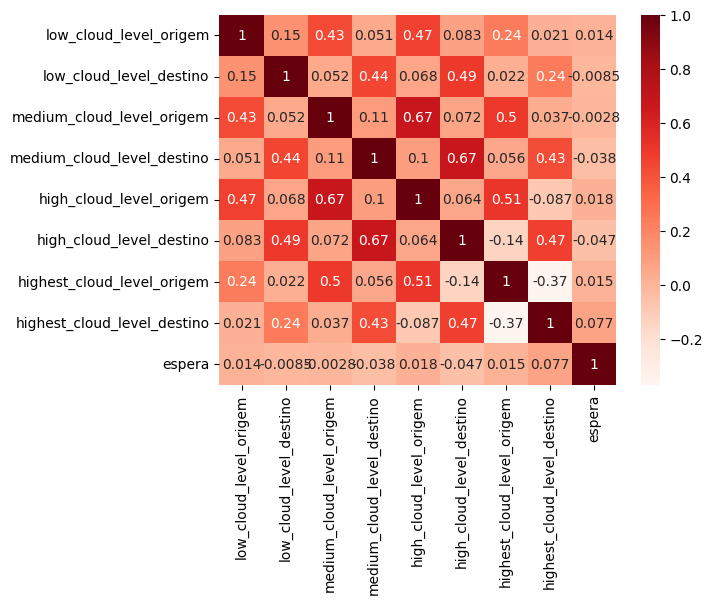

No strong correlation seems to appear between these predictors and the label, while there are some predictors strongly correlated to each other e.g. medium_cloud_level_destino and high_cloud_level_destino. All of this is expected from the way the metar report is structured.

In a first approach, we will however integrate all these predictors to our model.

#### Wind information

There are three columns refering to wind information:

- wind direction: ranges from 0 to 360, indicates where the wind is coming from, 360 is north, 270 west, 180 south and 90 east.
- wind speed: wind speed in knots
- wind gust: the presence of wind gust and its speed

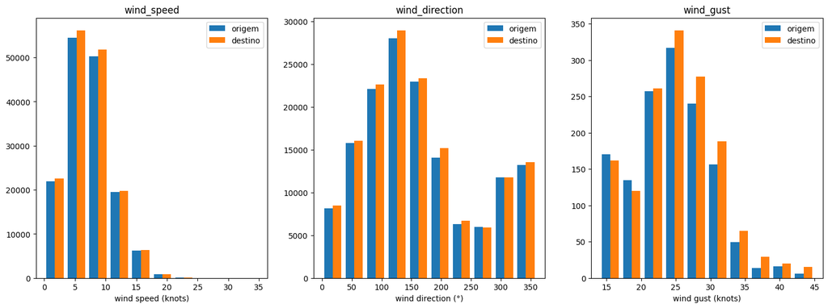

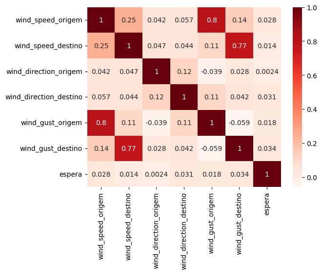

Wind gust and wind speed seem to be highly correlated, which makes sense.

Although no strong correlation can be seen between any predictor and the delays, we will use them as predictors for a first approach.

#### Visibility

The minimum visibility on the surface is given by the *visibility* column, in meters.

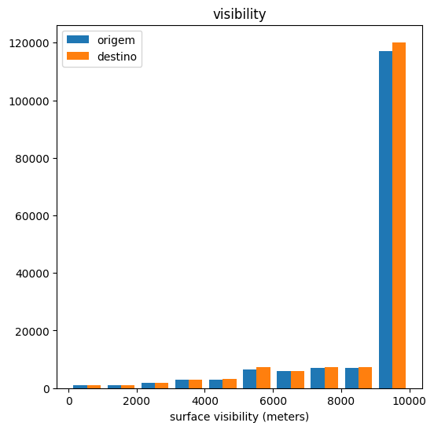

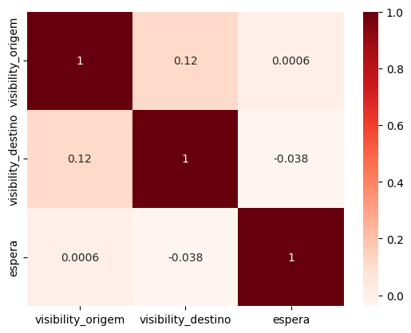

There doesn't seem to be a strong correlation between the visibility and the delay in the flights, making it a poor predictor.

#### Current weather

Information about the current local weather, including preciptation, thunderstorms and other weather events.

We will first combine and transform the information given in three columns *current_wx1*, *current_wx2* and *current_wx3* for both *origem* and *destino* into one single categorical column.

```
<class 'pandas.core.frame.DataFrame'>
Index: 169343 entries, 57224 to 54718
Data columns (total 81 columns):
 #   Column                            Non-Null Count   Dtype
---  ------                            --------------   -----
 0   flightid                          169343 non-null  object
 1   hora_ref                          169343 non-null  object
 2   origem                            169343 non-null  object
 3   destino                           169343 non-null  object
 4   url_img_satelite                  166993 non-null  object
 5   metaf                             71828 non-null   object
 6   metar                             168045 non-null  object
 7   prev_troca_cabeceira              169343 non-null  int64
 8   troca_cabeceira_hora_anterior     169343 non-null  int64
 9   espera                            169343 non-null  float64
```

[output cut: 73 more lines]

```
                   count      mean
current_wx_origem
+RA                   18  0.055556
VCSH                3647  0.028517
-RA                 6607  0.023611
VCTS                 814  0.023342
FG                  1081  0.020352
RA                  1761  0.015332
HZ                    73  0.013699
BR                 11940  0.013065
TS                   250  0.012000
-DZ                  720  0.006944
DZ                    16  0.000000
+DZ                    1  0.000000
VCFG                  14  0.000000
                    count      mean
current_wx_destino
+DZ                     9  0.333333
+RA                    20  0.100000
HZ                     75  0.080000
TS                    271  0.062731
-RA                  6861  0.042559
VCTS                  739  0.039242
RA                   1827  0.037767
VCSH                 3915  0.037037
FG                   1268  0.029968
-DZ                   743  0.018843
BR                  12375  0.016889
DZ                     13  0.000000
VCFG                    7  0.000000
```

Clearly, the delays vary with the different weather conditions, indicating that this set of predictors might be relevant for the model.

#### Cloud coverage

This information is related to the cloud types reported before. It represents how much of the sky is covered by clouds.

[figure not shown]

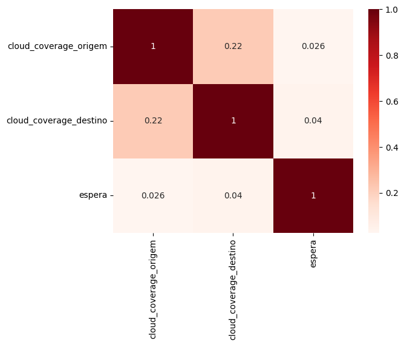

The delays increase with the increase in the sky coverage, which make sense, although the correlation is very weak.

As with other features, let's include this in the model for a first approach.

#### Temperature

Temperature and dewpoint

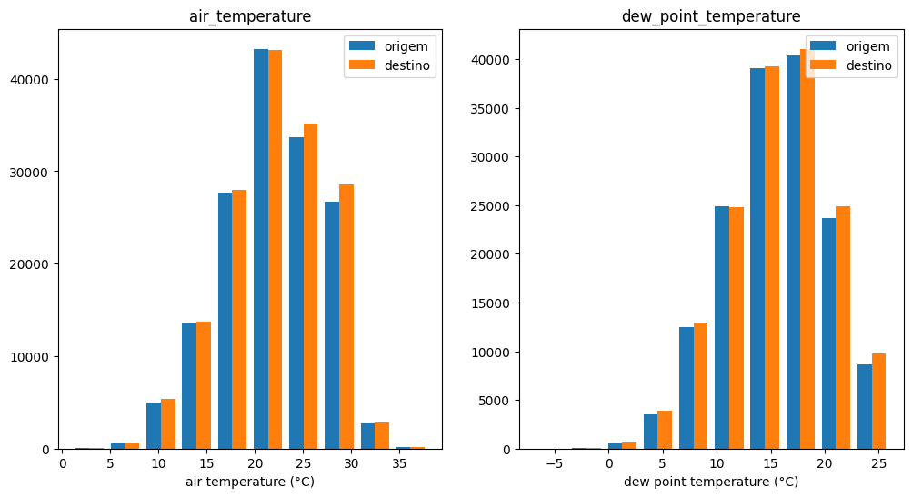

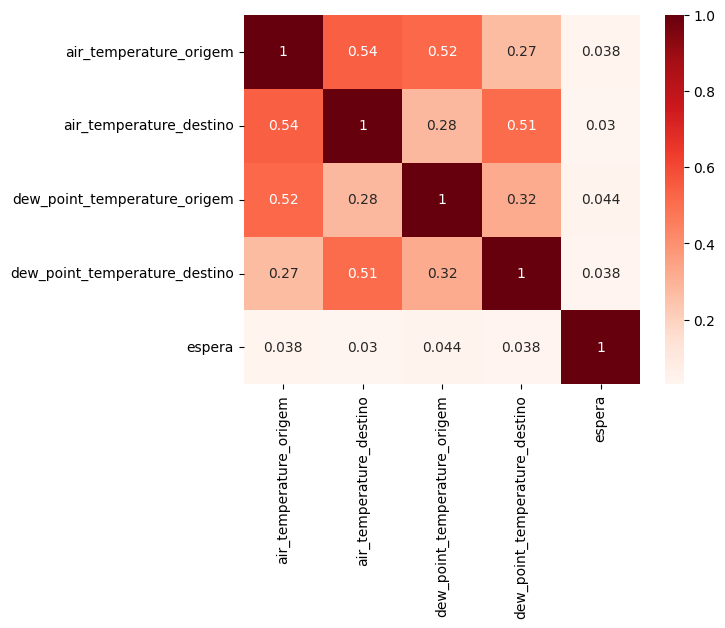

Delays seem to increase with increasing air temperatures and dewpoints.

Quite some correlation between air temperatures and dew points, which makes sense from the nature of these features. Also some correlation between air temperatures in departure and arrival points, indicating warmer or colder days in Brazil overall.

#### Altimeter

The current pressure at elevation of station.

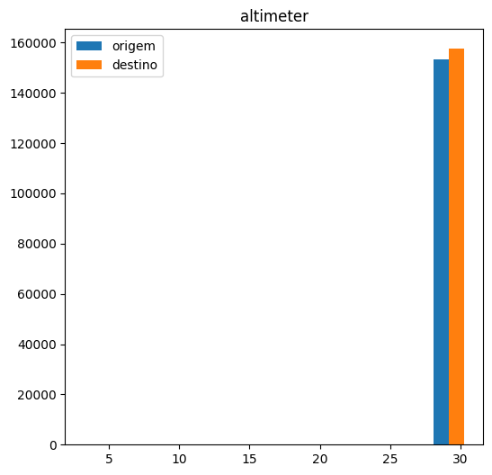

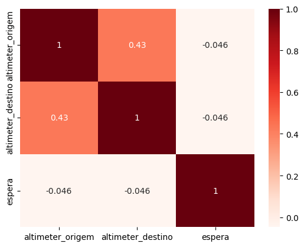

### Runway markings

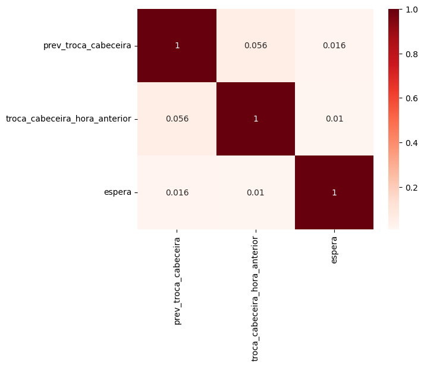

Not a lot of correlation between these predictors and the output.

As with all other features, we will include these in the model in a first approach.

### Images

Satelite imagery will be analyzed in a future work.

### Remaining info

## Feature engineering

### Custom transformers

Using the insights gained from the data exploration and visualization, I will now construct custom sklearn transformers to automate the feature extraction and transformation for this problem.

### Custom pipeline for feature generation

We define the features of interest, splitting them into numerical and categorical features.

A custom pipeline is built to handle all the feature extraction. This includes:

- Generating the route feature;
- Transforming the runway markings into a binary feature;
- Extracting the time features (day of week and period of day);
- Combining metar/metaf information, as discussed previously;
- Transforming the weather features into categorical that aggregates different reports.

```
<class 'pandas.core.frame.DataFrame'>
Index: 169343 entries, 57224 to 54718
Columns: 167 entries, flightid to current_wx_destino
dtypes: bool(2), category(4), float64(105), object(56)
memory usage: 210.3+ MB
```

### Imputing and scaling features

Missing values will be imputed using sklearn SimpleImputer following knowledge from the data we are working with:

- Numerical features such as wind direction, wind speed, temperatures will be imputed using the median of the observed values;
- Numerical features in which a null value represents no observation (wind gust) will be imputed using zero (knowledge about how METAR report works);
- Binary features will be imputed using the median.
- Cloud levels will be imputed using 10000 (knowledge about how METAR works);
- Categorical features non-related to weather will be imputed using most frequent approach.
- Numerical features will be standardized;
- Categorical features will be one hot encoded.

```
<class 'pandas.core.frame.DataFrame'>
RangeIndex: 169343 entries, 0 to 169342
Columns: 289 entries, num_median__wind_direction_origem to clouds_cat__highest_cloud_type_destino_SKC
dtypes: float64(289)
memory usage: 373.4 MB
<class 'pandas.core.series.Series'>
Index: 169343 entries, 57224 to 54718
Series name: espera
Non-Null Count   Dtype
--------------   -----
169343 non-null  float64
dtypes: float64(1)
memory usage: 2.6 MB
```

We end up with 289 features (including one hot encodings), for a dataset of 169343 samples, which represents a good amount of samples for features.

Surely, some features can lately be removed in a fine-tuning approach by observing their importance to the predictions of the model.

## Models

I will be using the sample weights gotten using adversarial sampling. An explanation about this technique can be found in the other notebook *adversarial.ipynb*

```
169343
```

### Model exploration

On a first approach, I will quickly explore different classifier models and then decide on which presents the best initial performance for this problem.

#### SGD classifier

```
time = 19.06 s
score = 0.7424470997672528
```

#### AdaBoost classifier

```
time = 120.26 s
score = 0.7448806892090056
```

#### LightGBM classifier

```
time = 21.28 s
score = 0.7840792120295046
```

#### XGBoost classifier

```
time = 21.23 s
score = 0.7729845760424616
```

### Final results

|  | time | score |
| --- | --- | --- |
| lightgbm | 21.28 | 0.784079 |
| xgboost | 21.23 | 0.772985 |
| adaboost | 120.26 | 0.744881 |
| sgd | 19.06 | 0.742447 |

Both LightGBM and XGBoost present fairly good performances on this problem, so we will explore both approaches.

The detailed exploration of both models can be found in the notebooks *lightbm.ipynb* and *xgboost.ipynb*.

## Submission

```
<class 'pandas.core.frame.DataFrame'>
RangeIndex: 90720 entries, 0 to 90719
Data columns (total 10 columns):
 #   Column                         Non-Null Count  Dtype
---  ------                         --------------  -----
 0   flightid                       90720 non-null  object
 1   hora_ref                       90720 non-null  object
 2   origem                         90720 non-null  object
 3   destino                        90720 non-null  object
 4   url_img_satelite               89925 non-null  object
 5   metaf                          66032 non-null  object
 6   metar                          90715 non-null  object
 7   prev_troca_cabeceira           90720 non-null  int64
 8   troca_cabeceira_hora_anterior  90720 non-null  int64
 9   espera                         0 non-null      float64
dtypes: float64(1), int64(2), object(7)
memory usage: 6.9+ MB
```

```
Pipeline(steps=[('features',
                 Pipeline(steps=[('cabeceira', CabeceiraTransformer()),
                                 ('time', TimeInformation()),
                                 ('combine_metar',
                                  CombineMetarTransformer(cat_features=['low_cloud_type_origem',
                                                                        'medium_cloud_type_origem',
                                                                        'high_cloud_type_origem',
                                                                        'highest_cloud_type_origem',
                                                                        'current_wx1_origem',
                                                                        'current_wx2_origem',
                                                                        'current_wx3_origem',
                                                                        'low_cloud_type_dest...
                               feature_types=None, gamma=0.3, grow_policy=None,
                               importance_type=None,
                               interaction_constraints=None, learning_rate=0.01,
                               max_bin=None, max_cat_threshold=None,
                               max_cat_to_onehot=None, max_delta_step=3,
                               max_depth=7, max_leaves=None, min_child_weight=1,
                               missing=nan, monotone_constraints=None,
                               multi_strategy=None, n_estimators=2000,
                               n_jobs=None, num_parallel_tree=None,
                               random_state=None, ...))])
```

```
datetime.date(2023, 2, 16)
```

```
[0.018179021775722504,
 0.13359399139881134,
 0.43254321813583374,
 0.026602106168866158,
 0.19340327382087708,
 0.1747806966304779,
 0.07686416059732437,
 0.056867651641368866,
 0.0762397050857544,
 0.19327466189861298]
```

```
{"proba":[0.011626668274402618,0.004717281088232994,0.026925399899482727,0.17511600255966187,0.3050905466079712,0.2964039146900177,0.1994696855545044,0.20396876335144043,0.05666625127196312,0.034269068390131]}
<bound method Response.json of <Response [200]>>
```

```
array([0, 0])
```

|  | flightid | hora_ref | origem | destino | url_img_satelite | metaf | metar | prev_troca_cabeceira | troca_cabeceira_hora_anterior | espera | ... | highest_cloud_type_destino_metaf | highest_cloud_level_destino_metaf | cloud_coverage_destino_metaf | air_temperature_destino_metaf | dew_point_temperature_destino_metaf | altimeter_destino_metaf | current_wx1_symbol_destino_metaf | current_wx2_symbol_destino_metaf | current_wx3_symbol_destino_metaf | remarks_destino_metaf |
| --- | --- | --- | --- | --- | --- | --- | --- | --- | --- | --- | --- | --- | --- | --- | --- | --- | --- | --- | --- | --- | --- |
| 202751 | d31d420792295a5f49c22b52ce9aa3fc | 2023-02-06 11:00:00+00:00 | SBRJ | SBKP | http://satelite.cptec.inpe.br/repositoriogoes/... | METAF SBKP 061100Z 27003KT 4000 BR OVC033... | METAR SBKP 061000Z 03003KT 9999 VCSH SCT018 FE... | 0 | 1 | 0.0 | ... | NaN | NaN | 8.0 | 21.0 | 19.0 | 29.943403 | 10.0 | 0.0 | 0.0 |  |
| 178860 | eeb65aaee72cde23e2ee66b9ad1eb8c6 | 2023-01-09 12:00:00+00:00 | SBCT | SBGR | http://satelite.cptec.inpe.br/repositoriogoes/... | METAF SBGR 091200Z 08004KT 9000 OVC033 ... | METAR SBGR 091100Z 14003KT 9999 OVC009 19/18 Q... | 0 | 0 | 0.0 | ... | NaN | NaN | 8.0 | 21.0 | 17.0 | 30.061523 | 0.0 | 0.0 | 0.0 |  |
| 98395 | d4ef329db1059800f14792114010a8b2 | 2022-10-04 16:00:00+00:00 | SBRF | SBCF | http://satelite.cptec.inpe.br/repositoriogoes/... | NaN | METAR SBCF 041500Z 31006KT 250V050 9999 SCT030... | 1 | 0 | 0.0 | ... | NaN | NaN | NaN | NaN | NaN | NaN | NaN | NaN | NaN | NaN |
| 35171 | c5f9ec4d53805cdb33ef241c249faae0 | 2022-07-16 17:00:00+00:00 | SBPA | SBGR | http://satelite.cptec.inpe.br/repositoriogoes/... | METAF SBGR 161700Z 32011KT CAVOK 27/09 Q1013= | METAR SBGR 161600Z 34012KT CAVOK 28/12 Q1016= | 0 | 1 | 0.0 | ... | NaN | NaN | 0.0 | 27.0 | 9.0 | 29.913873 | 0.0 | 0.0 | 0.0 |  |
| 28221 | c77ddb819a823f3f9e763990eda43463 | 2022-07-08 08:00:00+00:00 | SBRF | SBSP | http://satelite.cptec.inpe.br/repositoriogoes/... | METAF SBSP 080800Z 35003KT CAVOK 16/10 Q1022= | METAR SBSP 080700Z AUTO 07004KT 040V100 9000 N... | 0 | 0 | 0.0 | ... | NaN | NaN | 0.0 | 16.0 | 10.0 | 30.179643 | 0.0 | 0.0 | 0.0 |  |
| ... | ... | ... | ... | ... | ... | ... | ... | ... | ... | ... | ... | ... | ... | ... | ... | ... | ... | ... | ... | ... | ... |
| 60054 | 8065e2977beac633f388b5b4eebc8754 | 2022-08-16 16:00:00+00:00 | SBCT | SBKP | http://satelite.cptec.inpe.br/repositoriogoes/... | METAF SBKP 161600Z 32014KT CAVOK 30/07 Q1012= | METAR SBKP 161500Z 01015KT CAVOK 28/09 Q1016= | 0 | 0 | 0.0 | ... | NaN | NaN | 0.0 | 30.0 | 7.0 | 29.884343 | 0.0 | 0.0 | 0.0 |  |
| 19190 | 227c6c9abcc1963dcdf056e17ea3b904 | 2022-06-26 21:00:00+00:00 | SBSP | SBRJ | http://satelite.cptec.inpe.br/repositoriogoes/... | NaN | METAR SBRJ 262000Z 15007KT 120V180 9999 FEW020... | 0 | 1 | 0.0 | ... | NaN | NaN | NaN | NaN | NaN | NaN | NaN | NaN | NaN | NaN |
| 97223 | 347d258c122ae03cdcde402cc91db669 | 2022-10-03 10:00:00+00:00 | SBGR | SBGL | http://satelite.cptec.inpe.br/repositoriogoes/... | METAF SBGL 031000Z 31002KT 5000 BR OVC033... | METAR SBGL 030900Z 23002KT 9999 SCT006 BKN027 ... | 0 | 1 | 0.0 | ... | NaN | NaN | 8.0 | 20.0 | 17.0 | 30.002463 | 10.0 | 0.0 | 0.0 |  |
| 149843 | 10710eb0273ebc643f3eeda4335b8058 | 2022-12-05 18:00:00+00:00 | SBPA | SBSP | http://satelite.cptec.inpe.br/repositoriogoes/... | METAF SBSP 051800Z 14010KT 9999 -TSRA BKN02... | METAR SBSP 051700Z 03007KT 360V060 9999 -DZ SC... | 0 | 0 | 0.0 | ... | NaN | NaN | 6.0 | 26.0 | 19.0 | 29.825283 | 1095.0 | 0.0 | 0.0 |  |
| 120275 | a3e1bcc8f9efea2df7f931fa54a2edd7 | 2022-10-31 19:00:00+00:00 | SBKP | SBBR | http://satelite.cptec.inpe.br/repositoriogoes/... | NaN | METAR SBBR 311800Z 32004KT 9999 SCT030 FEW040T... | 1 | 0 | 0.0 | ... | NaN | NaN | NaN | NaN | NaN | NaN | NaN | NaN | NaN | NaN |

42336 rows × 122 columns

```
<sklearn.calibration.CalibrationDisplay at 0x212c206a810>
```

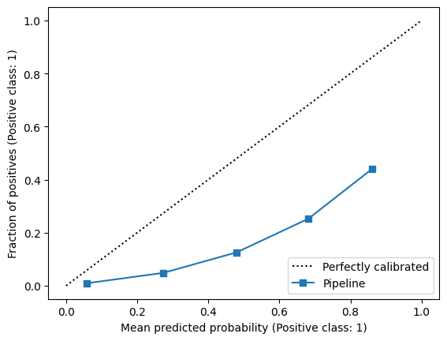

```
CalibratedClassifierCV(cv='prefit',
                       estimator=Pipeline(steps=[('features',
                                                  Pipeline(steps=[('cabeceira',
                                                                   CabeceiraTransformer()),
                                                                  ('time',
                                                                   TimeInformation()),
                                                                  ('combine_metar',
                                                                   CombineMetarTransformer(cat_features=['low_cloud_type_origem',
                                                                                                         'medium_cloud_type_origem',
                                                                                                         'high_cloud_type_origem',
                                                                                                         'highest_cloud_type_origem',
                                                                                                         'current_wx1_origem',
                                                                                                         'current_wx2_orig...
                                                                gamma=0.3,
                                                                grow_policy=None,
                                                                importance_type=None,
                                                                interaction_constraints=None,
                                                                learning_rate=0.01,
                                                                max_bin=None,
                                                                max_cat_threshold=None,
                                                                max_cat_to_onehot=None,
                                                                max_delta_step=3,
                                                                max_depth=7,
                                                                max_leaves=None,
                                                                min_child_weight=1,
                                                                missing=nan,
                                                                monotone_constraints=None,
                                                                multi_strategy=None,
                                                                n_estimators=2000,
                                                                n_jobs=None,
                                                                num_parallel_tree=None,
                                                                random_state=None, ...))]))
```

```
<sklearn.calibration.CalibrationDisplay at 0x212e4b74690>
```

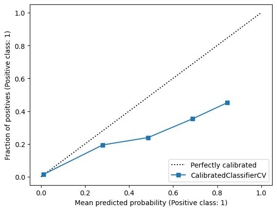

```
0    87067
1     3653
Name: count, dtype: int64
```

```
0    90437
1      283
Name: count, dtype: int64
```